# Spatial Aggregation Methods

Zarrar Khan

# Introduction

> For complete script go to https://github.com/zarrarkhan/rSpatialAggMethods  
> This summary does not show all code

Testing for three methods of spatial aggregation

1. Method 1 (m1): Spatial Points - Using Spatial Points Data Frames
2. Method 2 (m2): Raster Areas - Cropping a raster with a polygon using the raster area weights
3. Method 3 (m3): Polygon Areas - Cropping a polygon grid and using the subsequent polygon area weights

# Conceptual example of methods

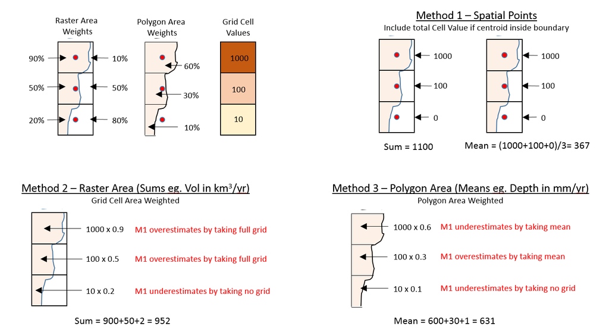

Methods Overview

**Conclusion:** * For volume (km<sup>3</sup>/yr) where need to sum use m2 which uses the grid cell weighted area * For depth (mm/yr) where need to take mean use m3 which takes the grid cell value and weights it by the polygon area

# Read Data

Read in polygon and raster data. In this example we use spatial boundaries from the GADM dataset for the region Argentina and Tethys water demand gridded outputs. All raw files available in the github repository.

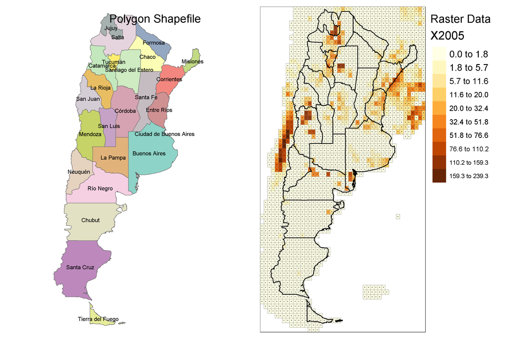

# Methods

## Method 1 – Spatial Points Data Frame

```r
tm<-system.time({  # system time
df1<-df
# Convert to Spatial Point Data Frames
df1 = SpatialPointsDataFrame(
      SpatialPoints(coords=(cbind(df1$lon,df1$lat))),
      data=df1)
proj4string(df1)<-projX
dfp<-raster::intersect(df1,shpa1);  # Crop to Layer shpa
gridded(dfp)<-TRUE  # Create Gridded Raster Data
}) # close system time
## SUM
tmS<-system.time({  # system time
dxp<-as.data.frame(dfp@data)
dxp<- dxp %>% subset(select=c("X2005","NAME_1")) %>%
              group_by(NAME_1) %>%
              summarise_all(funs(round(sum(.,na.rm=T),2))) %>% as.data.frame
sum_m1<-dxp}) # close system time
## MEAN
tmM<-system.time({  # system time
dxp<-as.data.frame(dfp@data)
dxp<- dxp %>% subset(select=c("X2005","NAME_1")) %>%
              group_by(NAME_1) %>%
              summarise_all(funs(round(mean(.,na.rm=T),2))) %>% as.data.frame
mean_m1<-dxp}) # close system time
##
names(sum_m1)[names(sum_m1)=="X2005"]<-"X2005m1"
names(mean_m1)[names(mean_m1)=="X2005"]<-"X2005m1"
sum_m1$timeSecm1<-tm[[3]]+tmS[[3]]
mean_m1$timeSecm1<-tm[[3]]+tmM[[3]]
```

## Method 2 – Raster Area

Method 2 uses the Weighted area of the raster grid cells. This method is appropriate for volume measurements where the sum is being taken.

```r
tm<-system.time({  # system time
w <- raster::extract(r,shpa1, method="simple",weights=T, normalizeWeights=F)
dfx<-data.frame()
for (i in seq(w)){
  x<-as.data.frame(w[[i]])
  x$ID<-shpa1@data$NAME_1[[i]]
  x$WeightedValue<-x$value*x$weight
  dfx<-rbind.data.frame(dfx,x)
}
names(dfx)[names(dfx)=="ID"]<-"NAME_1"
names(dfx)[names(dfx)=="WeightedValue"]<-"X2005m2"
## SUM
dxp<- dfx %>% subset(select=c("X2005m2","NAME_1")) %>%
  group_by(NAME_1) %>%
  summarise_all(funs(round(sum(.,na.rm=T),2))) %>% as.data.frame
sum_m2<-dxp
}) # close system time
sum_m2$timeSecm2<-tm[[3]];
```

## Method 3 – Polygon Area

Method 3 converts rasters to polygons and then uses the Weighted area of the cropped raster polygons. This method is appropriate for depth measurements where the mean is being taken.

```r
tm<-system.time({  # system time
  x<-raster::intersect(shpa1,rcropP)
  x@data<-x@data%>%dplyr::select(NAME_1,X2005)
  x@data$area<-area(x);
  s1<-shpa1
  s1$subRegAreaSum<-area(shpa1);head(s1)
  s1<-s1@data%>%dplyr::select(NAME_1,subRegAreaSum);
  x@data<-join(x@data,s1,by="NAME_1");
  x@data$areaPrcnt<-x@data$area/x@data$subRegAreaSum;
  x@data$X2005m3<-x@data$X2005*x@data$areaPrcnt;
  ## MEAN
  dxp<- x@data %>% subset(select=c("X2005m3","NAME_1")) %>%
    group_by(NAME_1) %>%
    summarise_all(funs(round(sum(.,na.rm=T),2))) %>% as.data.frame
  mean_m3<-dxp
}) # close system time
mean_m3$timeSecm3<-tm[[3]]
```

# Compare Methods

## Compare Sums - m1 vs m2

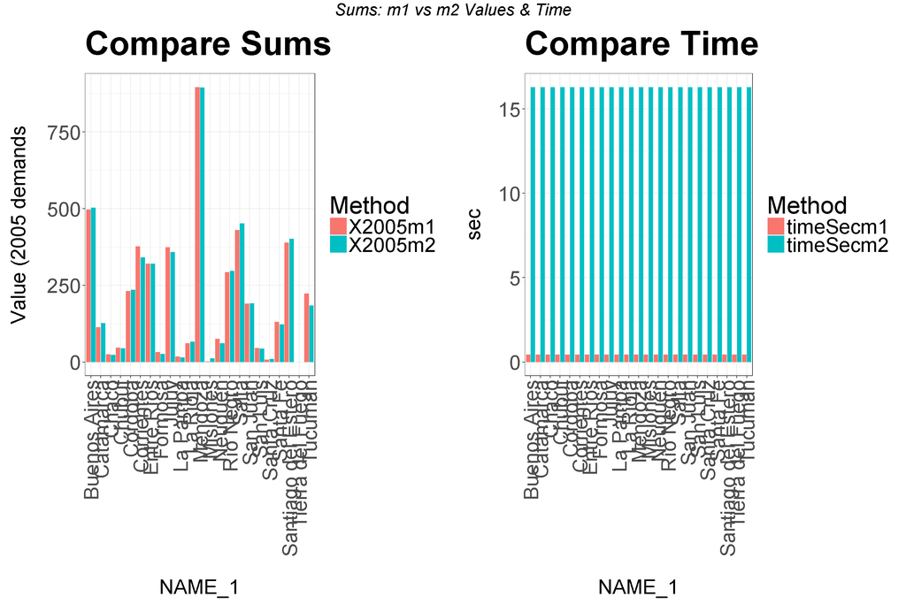

```r
library(grid);library(gridExtra)
grid.arrange(p1, p2, ncol=2,top = textGrob("Sums: m1 vs m2 Values & Time",gp=gpar(fontsize=20,font=3)))
```

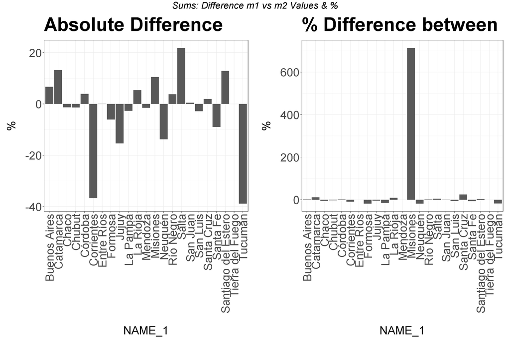

```r
grid.arrange(p3, p4, ncol=2,top = textGrob("Sums: Difference m1 vs m2 Values & %",gp=gpar(fontsize=20,font=3)))
```

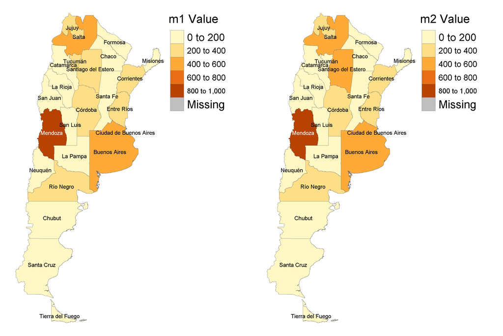

```r
tmap_arrange(tm1, tm2,asp = NA,ncol=2)
```

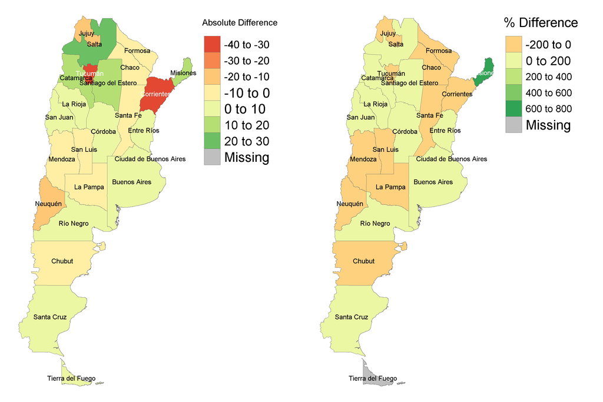

```r
tmap_arrange(tmdiffSum, tmdiffPrcntSum,asp = NA,ncol=2)
```

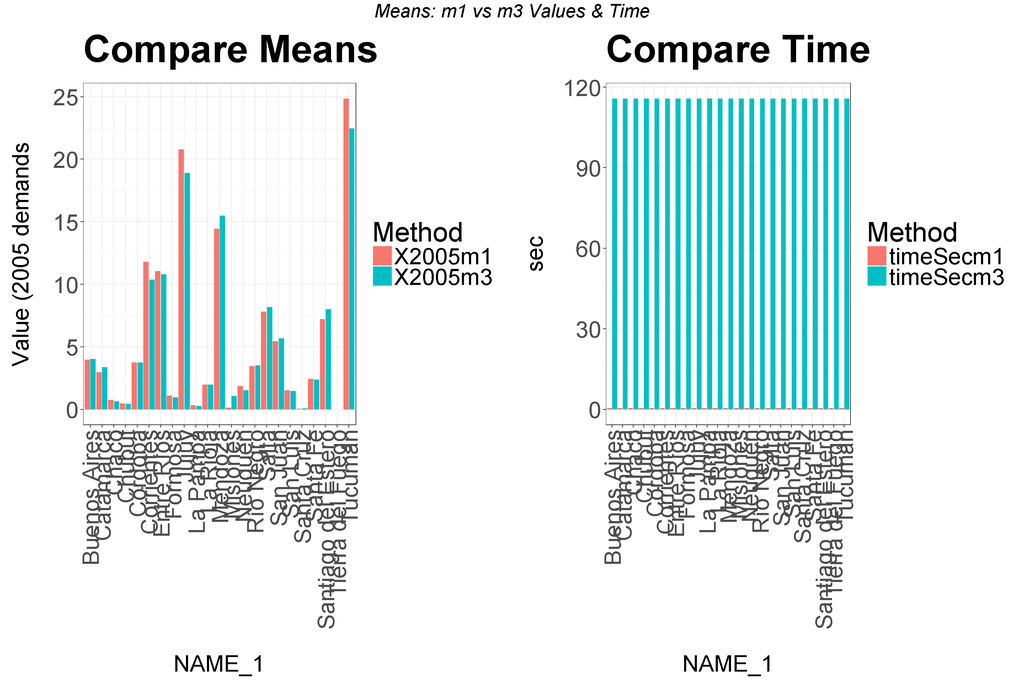

```r
library(grid);library(gridExtra)
grid.arrange(p1, p2, ncol=2,top = textGrob("Means: m1 vs m3 Values & Time",gp=gpar(fontsize=20,font=3)))
```

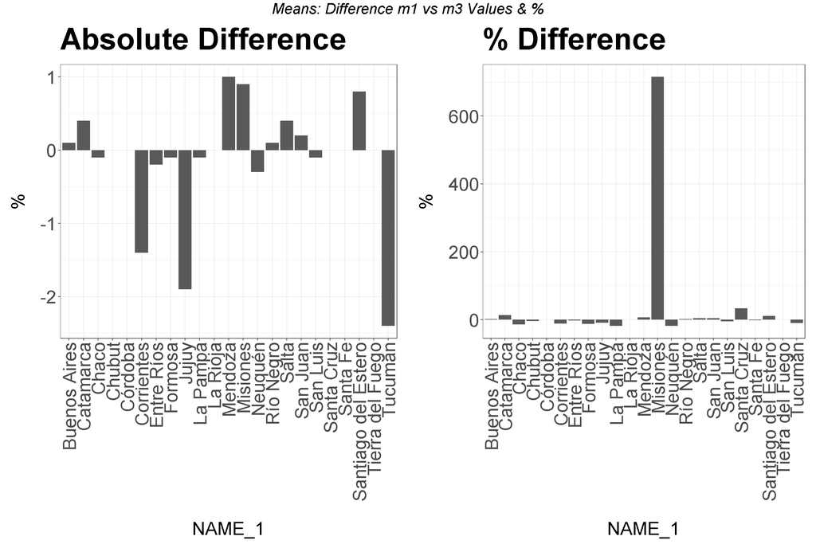

```r
grid.arrange(p3, p4, ncol=2,top = textGrob("Means: Difference m1 vs m3 Values & %",gp=gpar(fontsize=20,font=3)))
```

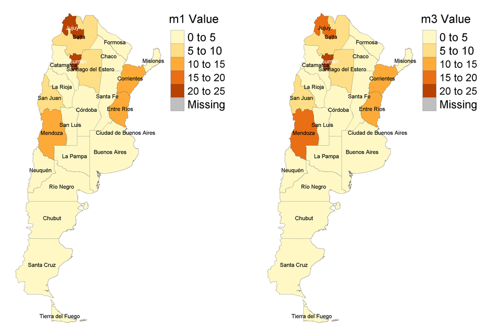

```r
tmap_arrange(tm1, tm2,asp = NA,ncol=2)
```

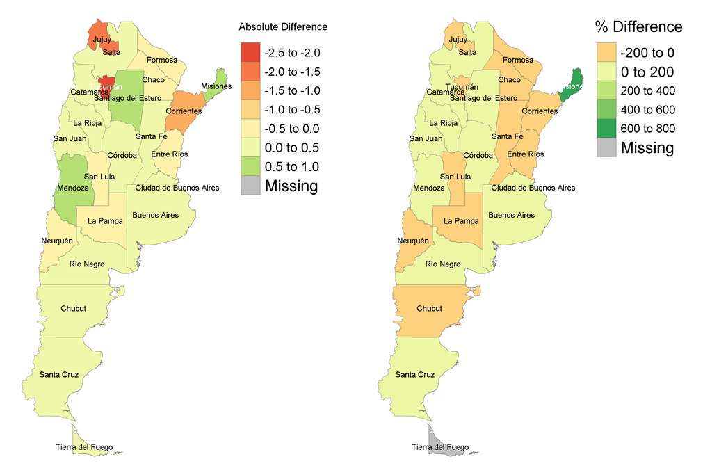

```r
tmap_arrange(tmdiffSum, tmdiffPrcntSum,asp = NA,ncol=2)
```

Summary of Sums Method 1 and Method 2

```r
diffSum
```

```
##                 NAME_1 X2005m1 X2005m2 diffm1m2 diffPrcntm1m2
## 1         Buenos Aires  496.85  503.52      6.7           1.3
## 2            Catamarca  113.26  126.51     13.2          11.7
## 3                Chaco   25.02   23.69     -1.3          -5.3
## 4               Chubut   46.61   45.22     -1.4          -3.0
## 5              Córdoba  231.62  235.53      3.9           1.7
## 6           Corrientes  377.49  340.77    -36.7          -9.7
## 7           Entre Ríos  320.28  320.38      0.1           0.0
## 8              Formosa   32.33   26.24     -6.1         -18.8
## 9                Jujuy  373.88  358.53    -15.4          -4.1
## 10            La Pampa   17.99   15.28     -2.7         -15.1
## 11            La Rioja   61.01   66.37      5.4           8.8
## 12             Mendoza  895.90  894.43     -1.5          -0.2
## 13            Misiones    1.47   11.95     10.5         712.9
## 14             Neuquén   75.09   61.32    -13.8         -18.3
## 15           Río Negro  292.85  296.69      3.8           1.3
## 16               Salta  430.07  451.85     21.8           5.1
## 17            San Juan  190.57  191.09      0.5           0.3
## 18            San Luis   46.23   43.38     -2.8          -6.2
## 19          Santa Cruz    7.68    9.59      1.9          24.9
## 20            Santa Fe  131.33  122.33     -9.0          -6.9
## 21 Santiago del Estero  389.14  402.06     12.9           3.3
## 22    Tierra del Fuego    0.00    0.00      0.0           NaN
## 23             Tucumán  223.62  184.72    -38.9         -17.4
```

Summary of Means Method 1 and Method 3

```r
diffMean
```

```
##                 NAME_1 X2005m1 X2005m3 diffm1m3 diffPrcntm1m3
## 1         Buenos Aires    3.97    4.03      0.1           1.5
## 2            Catamarca    2.98    3.37      0.4          13.1
## 3                Chaco    0.76    0.65     -0.1         -14.5
## 4               Chubut    0.47    0.45      0.0          -4.3
## 5              Córdoba    3.74    3.75      0.0           0.3
## 6           Corrientes   11.80   10.38     -1.4         -12.0
## 7           Entre Ríos   11.04   10.81     -0.2          -2.1
## 8              Formosa    1.11    0.97     -0.1         -12.6
## 9                Jujuy   20.77   18.90     -1.9          -9.0
## 10            La Pampa    0.33    0.27     -0.1         -18.2
## 11            La Rioja    1.97    1.97      0.0           0.0
## 12             Mendoza   14.45   15.48      1.0           7.1
## 13            Misiones    0.13    1.06      0.9         715.4
## 14             Neuquén    1.88    1.53     -0.3         -18.6
## 15           Río Negro    3.45    3.52      0.1           2.0
## 16               Salta    7.82    8.18      0.4           4.6
## 17            San Juan    5.44    5.69      0.2           4.6
## 18            San Luis    1.54    1.47     -0.1          -4.5
## 19          Santa Cruz    0.06    0.08      0.0          33.3
## 20            Santa Fe    2.43    2.39      0.0          -1.6
## 21 Santiago del Estero    7.21    8.02      0.8          11.2
## 22    Tierra del Fuego    0.00    0.00      0.0           NaN
## 23             Tucumán   24.85   22.45     -2.4          -9.7
```

# Selected Area

In this section we zoom into the area with the largest percentage difference (Misiones) and examine the differences closer.

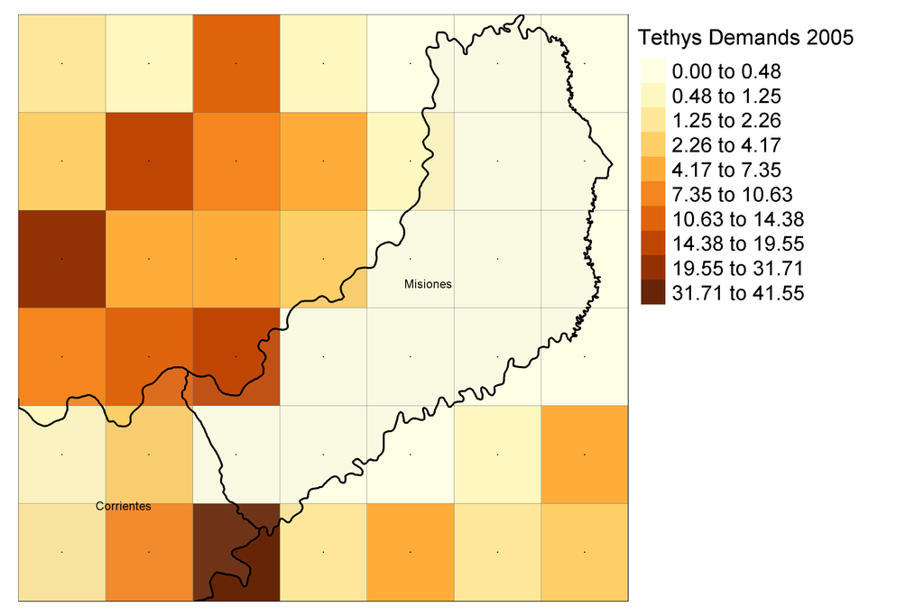

# Compare Methods Select Area

## Compare Sums - m1 vs m2

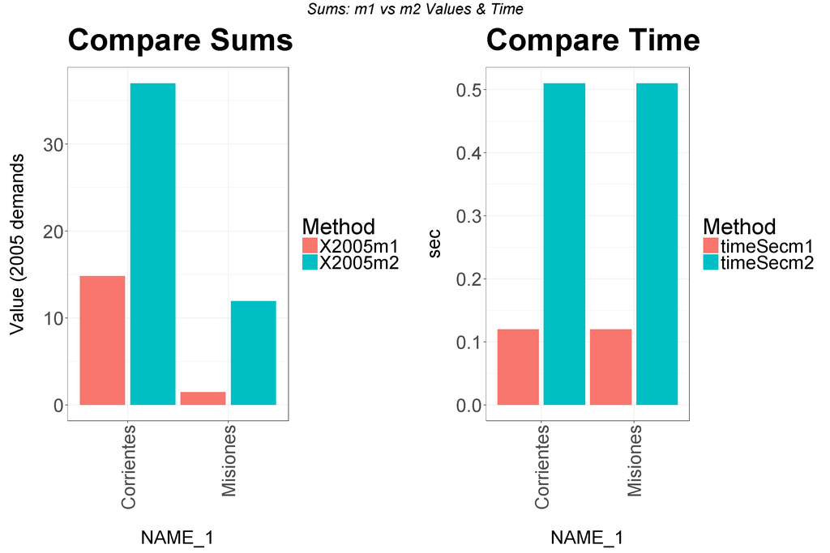

```r
library(grid);library(gridExtra)
grid.arrange(p1, p2, ncol=2,top = textGrob("Sums: m1 vs m2 Values & Time",gp=gpar(fontsize=20,font=3)))
```

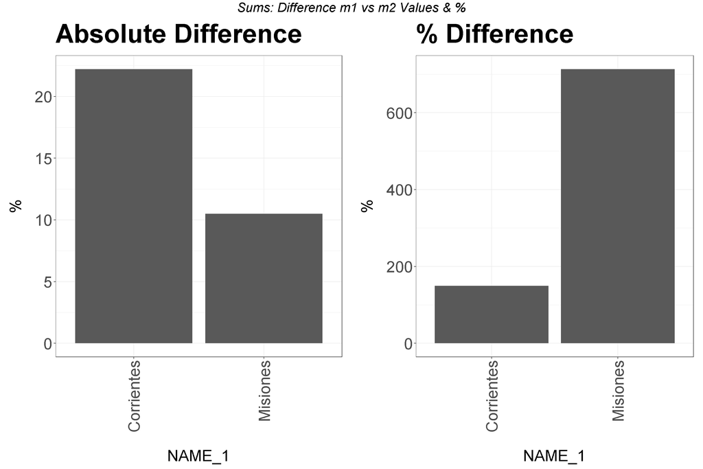

```r
grid.arrange(p3, p4, ncol=2,top = textGrob("Sums: Difference m1 vs m2 Values & %",gp=gpar(fontsize=20,font=3)))
```

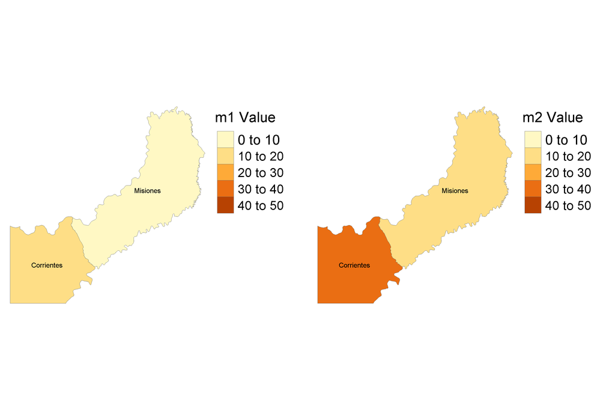

```r
tmap_arrange(tm1, tm2,asp = NA,ncol=2)
```

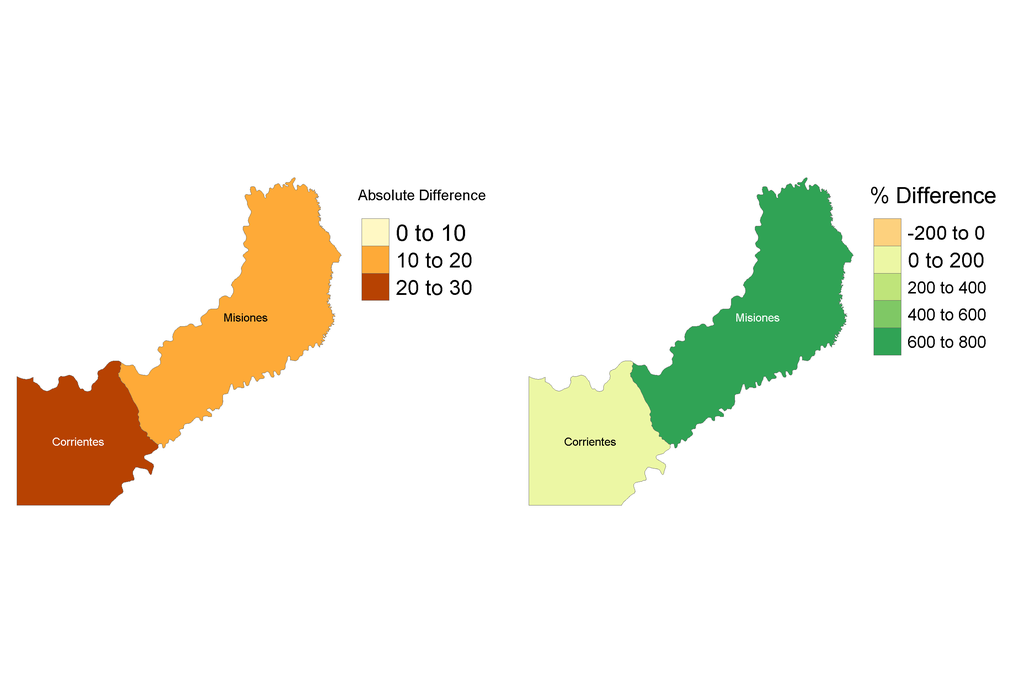

```r
tmap_arrange(tmdiffSum, tmdiffPrcntSum,asp = NA,ncol=2)
```

## Compare Means - m1 vs m3

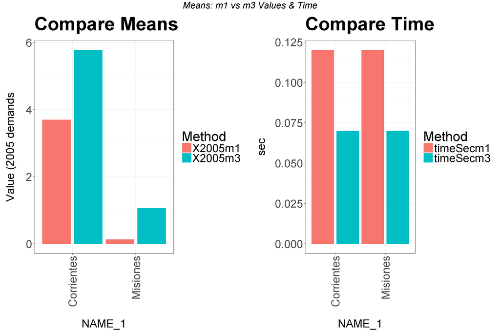

```r
library(grid);library(gridExtra)
grid.arrange(p1, p2, ncol=2,top = textGrob("Means: m1 vs m3 Values & Time",gp=gpar(fontsize=20,font=3)))
```

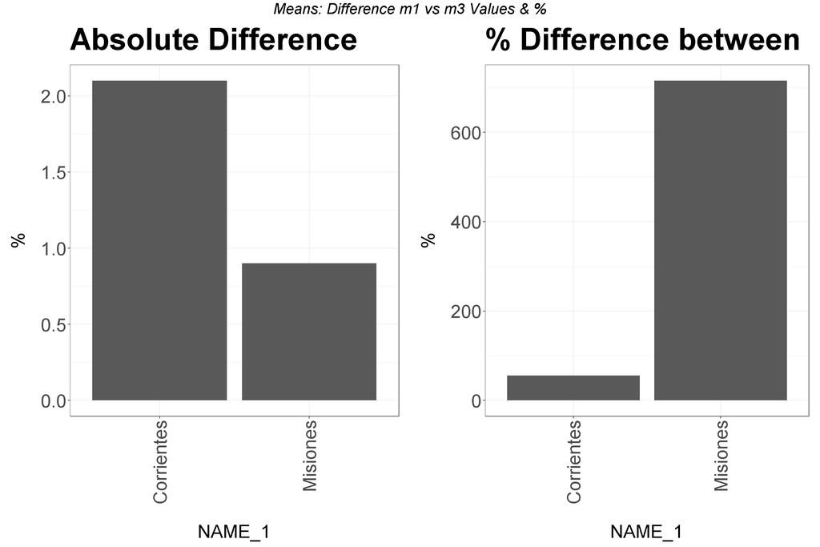

```r
grid.arrange(p3, p4, ncol=2,top = textGrob("Means: Difference m1 vs m3 Values & %",gp=gpar(fontsize=20,font=3)))
```

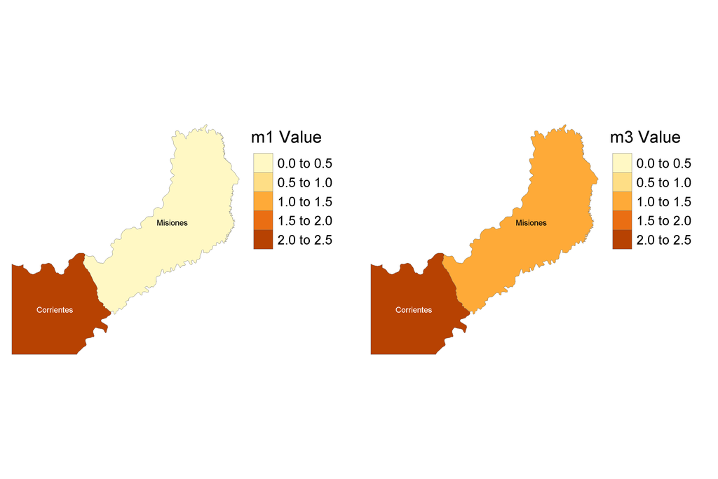

```r
tmap_arrange(tm1, tm2,asp = NA,ncol=2)
```

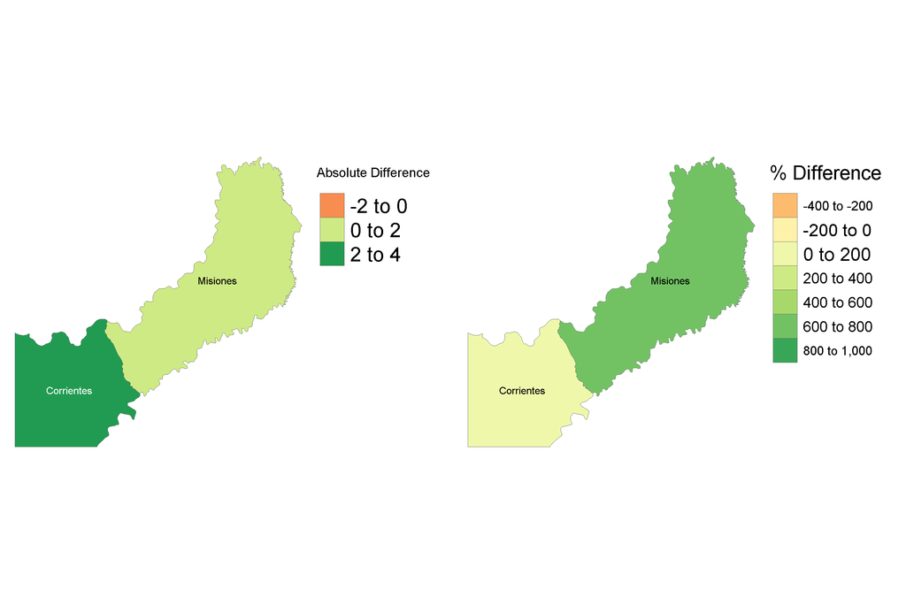

```r
tmap_arrange(tmdiffSum, tmdiffPrcntSum,asp = NA,ncol=2)
```

Summary of Sums Method 1 and Method 2

```r
diffSum
```

```
##       NAME_1 X2005m1 X2005m2 diffm1m2 diffPrcntm1m2
## 1 Corrientes   14.82   37.00     22.2         149.7
## 2   Misiones    1.47   11.95     10.5         712.9
```

Summary of Means Method 1 and Method 3

```r
diffMean
```

```
##       NAME_1 X2005m1 X2005m3 diffm1m3 diffPrcntm1m3
## 1 Corrientes    3.70    5.77      2.1          55.9
## 2   Misiones    0.13    1.06      0.9         715.4
```